# StatComp 2018 WC

Abgabe

Mathias Binder (Matr.Nr. 01268283), Attila Lázár (Matr.Nr. 0026842)

## Tools Used

We used R for our experiments and visualizations. First we load the libraries we will use. Some functions are masked by other libraries, we explicitly name them to avoid collisions.

```r
library(dplyr)
library(MASS)
library(rpart)
library(ggplot2)
library(GGally)
library(gridExtra)
library(tidyverse)
library(data.table)
library(futile.matrix)


# avoid collisions
select <- dplyr::select
arrange <- dplyr::arrange
filter <- dplyr::filter
```

### Historic WC Data

- **Task 1.** Get familiar with the data using `str()`, `head()`, `table()`, `summary()`, etc. Describe the data in a few lines.
- WorldCupPayers
- WorldCupMatches Historic WC Data contains relevant information regarding soccer games from World Cups beginning at 1930 and ending at 2014. The entries after 2014 are probably used for 2018 but are currently empty - they display NA

```r
WorldCup = read.csv("data/WorldCups.csv")
WorldCupPlay = read.csv("data/WorldCupPlayers.csv")

# Historical DAta
WorldCupMatch = read.csv("data/WorldCupMatches.csv")

# Task 1: Get familiar with the data using several functions.

#str(WorldCupMatch)
#head(WorldCupMatch)
#glimpse(WorldCupMatch)
#table(WorldCupMatch)
#summary(WorldCupMatch)
```

- **Task 2.** Write a function that generates the result of the game (W, D, L) from the vectors. How would you incorporate the information in the variable `Win.conditions`?

`Win.conditions` contains information if the game was decided with extra time or penalties. As we do predictions we will decide whether we use this games for training or we use only regularly decided games.

```r
result_code <- function(data, code) {
  ifelse(data[,7] > data[,8], code[1], ifelse(data[,7] == data[,8], code[2], code[3]))
}


#Get column with Results for the home team into the original dataframe - History of World Cups
Hist_Data = cbind(WorldCupMatch, result_code(WorldCupMatch, c("W","D","L")))
colnames(Hist_Data)[21]="Result.for.Home.Team"
```

- **Task 3.** Explore the data set using summary statistics and illustrations.
- How often has every nation participated?

```r
##How often has every nation participated
### NarrowData

Hist1 = Hist_Data %>%
  group_by(`Home.Team.Name`) %>%
  select(`Year`, `Home.Team.Name`)

Histunique = unique(Hist1)

###Gives a tibble with the frequency of participation of every country
count(Histunique)
```

```
## # A tibble: 79 x 2
## # Groups:   Home.Team.Name [79]
##    Home.Team.Name     n
##    <fct>          <int>
##  1 ""                 1
##  2 Algeria            4
##  3 Angola             1
##  4 Argentina         15
##  5 Australia          4
##  6 Austria            5
##  7 Belgium            8
##  8 Bolivia            1
##  9 Brazil            19
## 10 Bulgaria           4
## # ... with 69 more rows
```

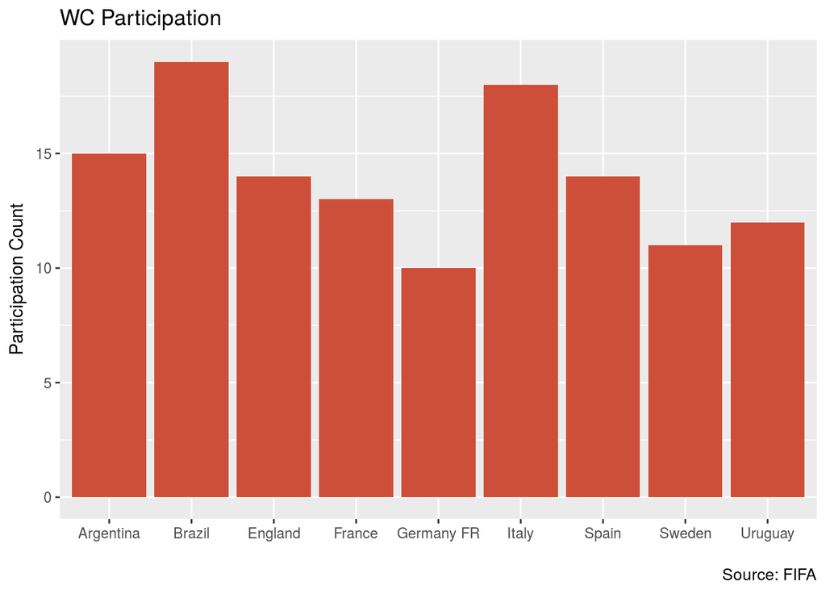

```r
### Visualization - Nation that participated most times

Numberofappearance = count(Histunique)
Numberofappearance = as.data.frame(Numberofappearance)
colnames(Numberofappearance) = c("Team", "nAppearance")
Numberofappearance = na.omit(Numberofappearance)

Numberofappearance %>%
  subset(nAppearance > 9) %>%
  arrange(desc(nAppearance)) %>%
  ggplot(aes(x = Team, y = nAppearance)) +
  geom_bar(stat = "identity",  fill="tomato3") +
    labs(title="WC Participation",
       caption="Source: FIFA",
       y="Participation Count",
       x="")
```

- Create a table with the number of wins/draws/losses for ever nation.

```r
head(
Hist_Data %>%
  select(`Home.Team.Name`, `Result.for.Home.Team`) %>%
  group_by(`Home.Team.Name`) %>%
  summarise(
    wins = sum( ifelse( Result.for.Home.Team == "W", 1, 0 ) ),
    draws = sum( ifelse( Result.for.Home.Team == "D", 1, 0 ) ),
    losses = sum( ifelse( Result.for.Home.Team == "L", 1, 0 ) )
  )  %>%
  arrange(desc(wins))
)
```

```
## # A tibble: 6 x 4
##   Home.Team.Name  wins draws losses
##   <fct>          <dbl> <dbl>  <dbl>
## 1 Brazil           59.   14.     9.
## 2 Argentina        41.    5.     8.
## 3 Italy            38.   14.     5.
## 4 Germany FR       29.   13.     1.
## 5 Germany          24.    5.     5.
## 6 England          22.   11.     2.
```

- How many goals were scored on average by ever nation?
- etc.

```r
Home1 = Hist_Data %>%
  select(`Home.Team.Name`, `Home.Team.Goals`)

Away1 = Hist_Data %>%
  select(`Away.Team.Name`, `Away.Team.Goals`)

colnames(Home1) = c("Team", "Goals")
colnames(Away1) = c("Team", "Goals")

HomeAway = rbind(Home1, Away1)

HomeAway1 = HomeAway %>%
  group_by(`Team`)

head(
  HomeAway1 %>%
    group_by(`Team`) %>%
    summarise(mean = mean(`Goals`)) %>%
    arrange(desc(mean))
)
```

```
## # A tibble: 6 x 2
##   Team        mean
##   <fct>      <dbl>
## 1 Hungary     2.72
## 2 Germany     2.17
## 3 Germany FR  2.11
## 4 Brazil      2.08
## 5 Turkey      2.00
## 6 France      1.77
```

- **Task 4.** Do you think this data set can be used to build a predictor function?

Since this dataset contains result from countries over a long period of time one can investigate trends regarding the strength of any Team. However Teams are changing and their trainers are changing. After a few years the whole Team is completely new and therefore it is possible to get entirely different results. So maybe an overall trend can be observed but to predict, it would be much more accurate to use latest results. Germany is a good example. Being the World Champion before this WC they struggled to maintain good performance e.g. against Austria. In this WC they didn´t make it to the next round and are on the last position in that group. From Historic WC Data this wouldn´t have been possible to predict and many ML algorithms predicted Germany to be champion this year.

### FIFA Ranking Data

- **Task 5.** Get familiar with the data using `str()`, `head()`, `table()`, `summary()`, etc.
- **Task 6.** What is the class of `fifa.ranking$rank_date`? Is this a problem? Can you change it to class `date` using `as.Date`? What difference does this make for e.g. plotting?

We use `mutate` from `dplyr` package to convert `rank_date`. This conversion is necessary because, as we can see later in the plots, the plotting library can format the dates appropriately. Also we could analyse the data as a timeseries if we choose to.

```r
ranking <- read.csv("data/fifa_ranking.csv")  %>%
  mutate (
    rank_date = as.Date(rank_date)
  )
```

- **Task 7.** Plot the FIFA ranks for a selection of favorites If you use `ggplot()` don’t forget to `scale_y_reverse()``

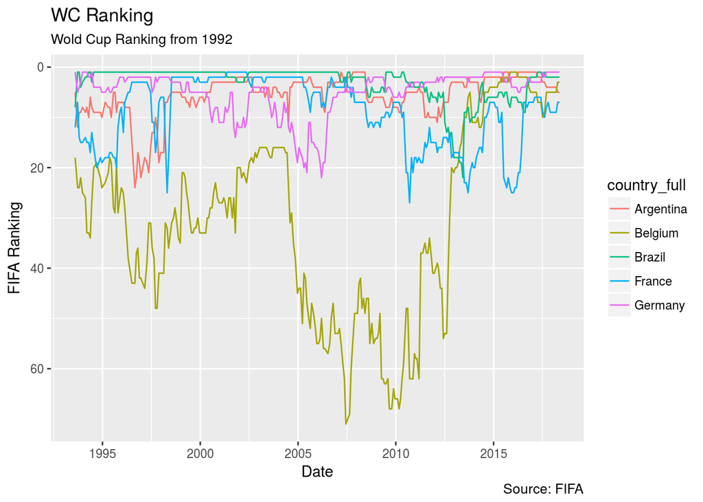

```r
favorites <- c("Germany", "Brazil", "Belgium", "France", "Argentina")

favs_ts <- ranking %>%
  filter(country_full %in% favorites)


ggplot(favs_ts, aes(x=rank_date)) +
  geom_line(aes(y=rank, col=country_full)) +
  scale_y_reverse() +
  labs(title="WC Ranking",
       subtitle="Wold Cup Ranking from 1992",
       caption="Source: FIFA",
       y="FIFA Ranking",
       x="Date")
```

Besides an overal $rank$ the data also provides various other variables. To get an idea about the numbers we plotted some of them for Germany.

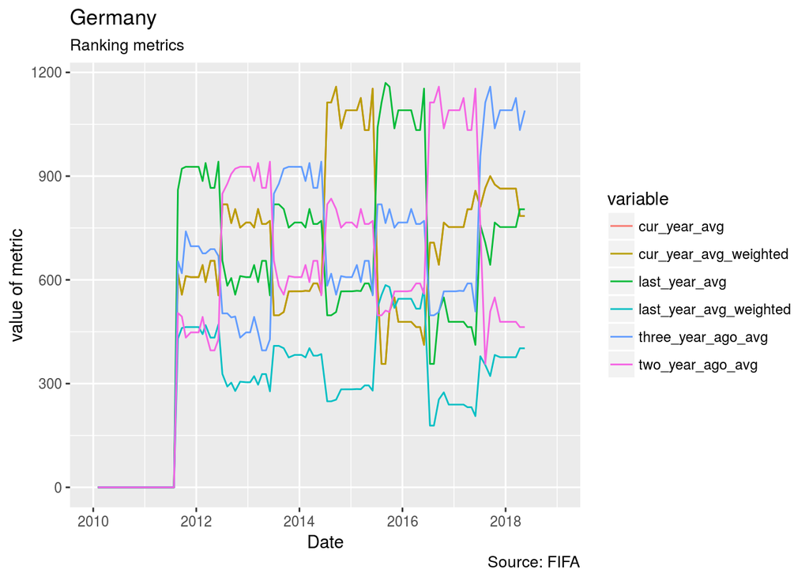

```r
ranking_de <- ranking  %>%
  filter(
    country_abrv == "GER"
  )  %>%
  select(
    rank_date,
#    cur_year_avg,
#    cur_year_avg_weighted
 matches("*avg*"),
 - country_full,
 - country_abrv,
 - confederation
         ) %>%
  gather(key = "variable", value = "value", -rank_date)

ggplot(ranking_de, aes(x = rank_date, y = value)) +
  geom_line(aes(color = variable)) +
  xlim(c(as.Date("2010-01-01"),as.Date("2019-01-01"))) +
#  scale_color_manual(values = c("#00AFBB", "#E7B800")) +
  labs(title="Germany",
       subtitle="Ranking metrics",
       caption="Source: FIFA",
       y="value of metric",
       x="Date")
```

```r
med_rank_by_country <- ranking %>%
arrange(rank_date)  %>%
group_by(country_abrv) %>%
  summarise(
    med_rank = median(rank),
    last_rank = last(rank)
) %>%
  transmute(country_abrv = as.character(country_abrv),
           med_rank = med_rank,
           last_rank = last_rank)

first20 <- med_rank_by_country[1:20,] %>%
  arrange(last_rank)  %>%
  transmute(
    country_abrv = as.factor(country_abrv),
            med_rank = med_rank,
           last_rank = last_rank)

head(first20)
```

```
## # A tibble: 6 x 3
##   country_abrv med_rank last_rank
##   <fct>           <dbl>     <int>
## 1 BEL               29.         3
## 2 ARG                5.         5
## 3 AUT               49.        26
## 4 AUS               48.        40
## 5 ALB               85.        56
## 6 ALG               57.        64
```

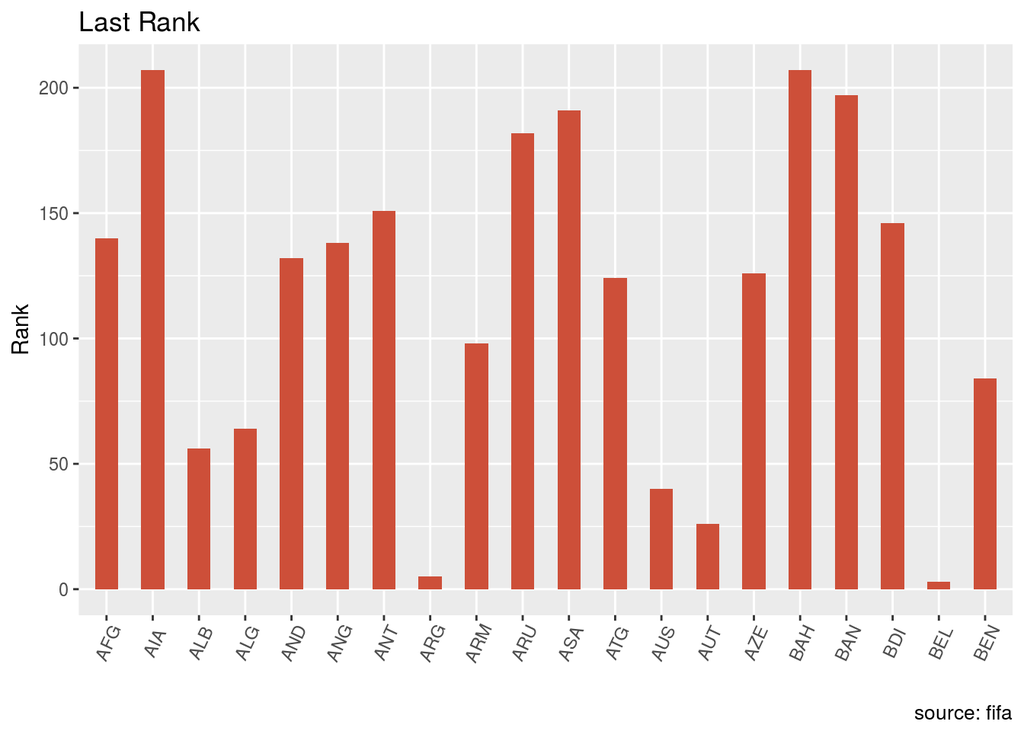

```r
ggplot(first20, aes(x=country_abrv, y=last_rank)) +
  geom_bar(stat="identity", width=.5, fill="tomato3") +
  labs(title="Last Rank",
       caption="source: fifa",
       y="Rank",
       x="") +
  theme(axis.text.x = element_text(angle=65, vjust=0.6))
```

### Transfermarkt.de Data

- **Task 8.** Have a look at the following web site https://www.transfermarkt.com/weltmeisterschaft-2018/startseite/pokalwettbewerb/WM18. Where can you find detailed information from the past world cups?
- **Task 9.** (voluntary) Browse the vignette of the following package:

```r
#library(rvest)
```

- **Task 10.** (voluntary) How can you scrape the relevant information of the following websites (in the order of the vector `participants`)?

```r
links.transfermarkt <- c(
  "https://www.transfermarkt.com/argentinien/startseite/verein/3437",
  "https://www.transfermarkt.com/australien/startseite/verein/3433",
  "https://www.transfermarkt.com/belgien/startseite/verein/3382",
  "https://www.transfermarkt.com/brasilien/startseite/verein/3439",
  "https://www.transfermarkt.com/kolumbien/startseite/verein/3816",
  "https://www.transfermarkt.com/costa-rica/startseite/verein/8497",
  "https://www.transfermarkt.com/kroatien/startseite/verein/3556",
  "https://www.transfermarkt.com/danemark/startseite/verein/3436",
  "https://www.transfermarkt.com/agypten/startseite/verein/3672",
  "https://www.transfermarkt.com/england/startseite/verein/3299",
  "https://www.transfermarkt.com/frankreich/startseite/verein/3377",
  "https://www.transfermarkt.com/deutschland/startseite/verein/3262",
  "https://www.transfermarkt.com/island/startseite/verein/3574",
  "https://www.transfermarkt.com/iran/startseite/verein/3582",
  "https://www.transfermarkt.com/japan/startseite/verein/3435",
  "https://www.transfermarkt.com/sudkorea/startseite/verein/3589",
  "https://www.transfermarkt.com/mexiko/startseite/verein/6303",
  "https://www.transfermarkt.com/marokko/startseite/verein/3575",
  "https://www.transfermarkt.com/nigeria/startseite/verein/3444",
  "https://www.transfermarkt.com/panama/startseite/verein/3577",
  "https://www.transfermarkt.com/peru/startseite/verein/3584",
  "https://www.transfermarkt.com/polen/startseite/verein/3442",
  "https://www.transfermarkt.com/portugal/startseite/verein/3300",
  "https://www.transfermarkt.com/russland/startseite/verein/3448",
  "https://www.transfermarkt.com/saudi-arabien/startseite/verein/3807",
  "https://www.transfermarkt.com/senegal/startseite/verein/3499",
  "https://www.transfermarkt.com/serbien/startseite/verein/3438",
  "https://www.transfermarkt.com/spanien/startseite/verein/3375",
  "https://www.transfermarkt.com/schweden/startseite/verein/3557",
  "https://www.transfermarkt.com/schweiz/startseite/verein/3384",
  "https://www.transfermarkt.com/tunesien/startseite/verein/3670",
  "https://www.transfermarkt.com/uruguay/startseite/verein/3449"
)
```

What kind of css selectors are there? https://www.w3schools.com/cssref/css_selectors.asp How can you use them to extract the information?

hint: use `read_html()`, `html_nodes()` with the css selectors “.item” or “td”, `html_children()`, etc.

### Socio-economic Data

- **Task 11.** Get familiar with the data using `str()`, `head()`, `table()`, `summary()`, etc. Describe the data in a few lines.

In order to be able to merge this dataset by coutryname, we introduce a new variable `key`.

```r
countries <- read.csv("data/countries of the world.csv", dec = ",", strip.white=TRUE) %>%
  arrange(Region)  %>%
  mutate(
    key = gsub("&", "and", trimws(Country)),
  )
```

- **Task 12.** Link the FIFA Ranks with this data by means of the country names and generate a scatterplot of the rank against the population, gdp etc. Which of the socio economic variables contains some information about the teams performance?

From the FIFA-Ranks data we calculated 3 variables:

- med_rank: the median rank over the whole dataset
- mean_rank: the mean rank over the whole dataset
- last_rank: last recorded rank for the country

```r
#calculate median rank
# TODO find better metrics of rank
med_rank_by_country <- read.csv("data/fifa_ranking.csv")  %>%
  arrange(rank_date)  %>%
  group_by(country_full) %>%
  summarise(
    med_rank = median(rank),
    mean_rank = mean(rank),
    last_rank = last(rank)
  ) %>%
  arrange(med_rank)  %>%
  transmute(
    country_full =country_full,
            med_rank = med_rank,
            mean_rank = mean_rank,
            last_rank = last_rank,
            key =  gsub("&", "and", trimws(as.character(country_full)))
  )

head(med_rank_by_country)
```

```
## # A tibble: 6 x 5
##   country_full med_rank mean_rank last_rank key
##   <fct>           <dbl>     <dbl>     <int> <chr>
## 1 Brazil             1.      3.18         2 Brazil
## 2 Germany            4.      5.12         1 Germany
## 3 Argentina          5.      5.46         5 Argentina
## 4 Spain              5.      5.31         8 Spain
## 5 France             7.      8.96         7 France
## 6 Netherlands        7.      8.86        19 Netherlands
```

To merge the `FIFA Ranking` with the `Countries` dataset we grouped the `FIFA Ranking` by country_full. Additionally we generated a `key` variable for merging with `Countries` using the same string-transformations as in the `Countries` dataset.

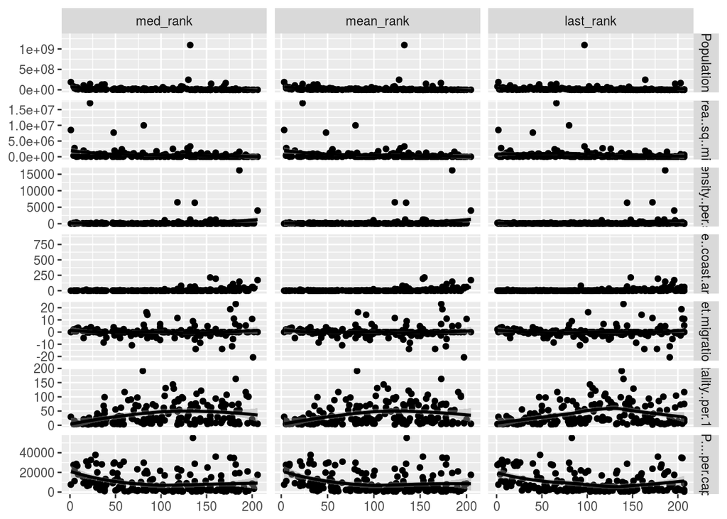

```r
country_rank <- merge(med_rank_by_country, countries , by="key", all=TRUE)

# only show numeric variables
numeric_cols <- names(select_if(country_rank, is.numeric))
#ggpairs(country_rank, columns = c("med_rank", "Population", "Area..sq..mi..",""))
ggduo(country_rank, c("med_rank", "mean_rank", "last_rank"), numeric_cols[4:(length(numeric_cols)/2)] )
```

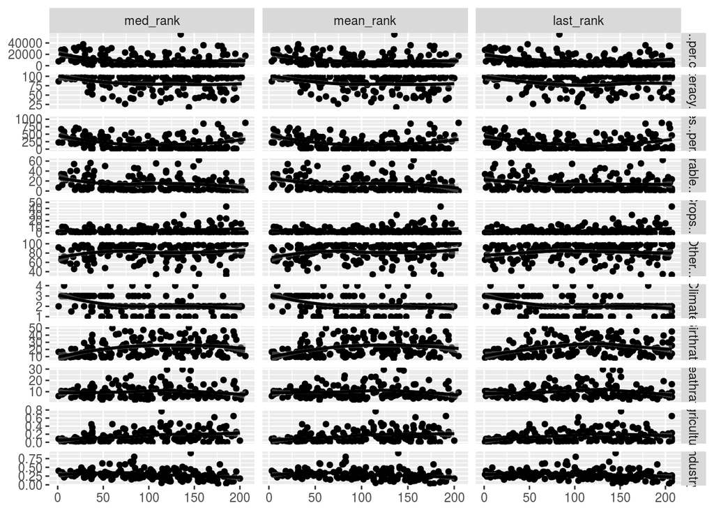

```r
ggduo(country_rank, c("med_rank", "mean_rank", "last_rank"), numeric_cols[(length(numeric_cols)/2):length(numeric_cols)] )
```

### Evaluation

- **Task 13.** Implement the evaluation metric. This is a function with two arguments: the prediction matrix $R$ and a data structure with the true results $R_{true}$. Note, that this data structure should not be a matrix since two teams may compete twice against each other during the course of a world cup tournament. What data structure would you suggest?

We implemented the evaluation metric as a simple function with the parameters:

- prediction: a symmetrical matrix with all participants in the rows/columns. Match outcomes are coded as ‘W’,‘D’ or ‘L’
- results: dataframe containing real results with columns home.team, away.team and result

The function returns the calculated accuracy of the predictions.

```r
evaluate.wm <- function(prediction, results) {
     results <- results %>%
     mutate(
       accurate = if (!is.na(result)) {result == prediction[home.team][away.team]} else { NA }
     )
   sum(results$accurate, na.rm=TRUE)/sum( !is.na( results$result ) )
}
```

- **Task 14.** Generate a matrix of random predictions to test this function. Don’t forget, that this matrix is symmetric and that the diagonal should only contain NAs.

For generating the prediction matrix for our evaluation function, we construct an empty matrix and fill it with predictions. In this case the predictions are random values.

```r
# all teams participating 2018
teams.all <- c("Russia", "Portugal", "France", "Argentina", "Saudi Arabia", "Spain", "Australia", "Iceland", "Egypt", "Morocco", "Peru", "Croatia", "Uruguay", "Iran", "Denmark", "Nigeria", "Brazil", "Germany", "Belgium", "Poland", "Switzerland", "Sweden", "Panama", "Senegal", "Costa Rica", "Mexico", "Tunisia", "Colombia", "Serbia", "Korea Republic", "England", "Japan")

#generate prediction matrix

#teams: array of team-names
#predict_function: name of predict funtion
#predict_args: additional args to pass to predict_function
predict.matrix <- function(teams, predict_function, predict_args = NULL) {

  m <- matrix(0, nrow = length(teams), ncol = length(teams), dimnames = list(teams, teams))
  diag(m) <- NA

  for(j in 1:ncol(m)){
    for(i in 1:nrow(m)){
      if (i != j) {
        args <- list(colnames(m)[i], colnames(m)[j])
        m[i,j] = do.call(predict_function, c(args,list(predict_args)))
      }
    }
  }
  m
}

#random prediction function

predict.random <- function(home, away, x) {
  code <- c("W", "D", "L")
  code[sample(1:3, 1, replace=TRUE)]
}
peek(predict.matrix(teams.all, predict.random), 5)
```

```
##              Russia Portugal France Argentina Saudi Arabia
## Russia       NA     "W"      "D"    "W"       "D"
## Portugal     "L"    NA       "W"    "L"       "W"
## France       "W"    "D"      NA     "L"       "D"
## Argentina    "W"    "W"      "D"    NA        "W"
## Saudi Arabia "W"    "L"      "D"    "L"       NA
```

- **Task 15.** Generate (hypothetic) true results and test the function of Task 14.

We use real data from the WC 2018. The data contains the variable $res$ which encodes the results in “1”, “2” and “X”. We have to translate it in our WDL code.

```r
fifa.results <- read.csv("data/fifa-world-cup-2018-RussianStandardTime-Results.csv", stringsAsFactors=TRUE, strip.white=TRUE, na.strings = "") %>%
  transmute(
    home.team= Home.Team,
    away.team=Away.Team,
    result = ifelse(res=="1","W",ifelse(res=="2", "L", ifelse(res=="X", "D", NA)))
  )
```

- **Task 16.** A completely naive predictor, which randomly predicts the outcome with equal probabilities, should serve as a benchmark. What is the expected rate of correct predictions?

There are 3 possibilities for the outcome of a game. If all three are equally probable, $P(X)=1/3$, so our accuracy should be around $0.33$.

```r
set.seed(33)
evaluate.wm(predict.matrix(teams.all, predict.random), fifa.results)
```

```
## [1] 0.3214286
```

### Prediction

- **Task 17** Choose a (first) model for a predictor. Clearly state your modelling assumptions and any decisions you made also during the foramting of the data, e.g.
  - use only results after 90 minutes.
  - use only data after 1994
  - which identifier was used to merge the data sets.

Since the data availability varies between data sets, clearly state how you want to fit and evaluate your predictor. The availability of the selected data sets is as follows:

```
- Historic WC data is available since the 1930s
- FIFA ranks are available since 1993,
- the full player's data is available for the 2018 world cup only,
- the market value of a player is available since 2006.
```

For other sources of data the availability might be different. Thus, we need a good strategy for bulding a classifier and evaluating it.

If you want to use information such as scored goals, caps, etc. for every player, then the only possiblity would be the qualifiers. Where can be obtain the results?

#### Training Data

We decided to train our models on the `WorldCupMatches` and the `FIFA Ranking` datasets.

```r
matches <- read.csv("data/WorldCupMatches.csv")  %>%
   filter(
       Away.Team.Name %in% teams.all | Home.Team.Name %in% teams.all,
       Year >= 1990,
       Win.conditions != ""
   )
```

#### Possion Model

According to this model the probability of the goals scored by one team is possion distributed. We inspect one team, `Argentina`. First we only count scores by the team. As comparison we draw the theoretical poisson distribution with $\lambda = mean(goals)$.

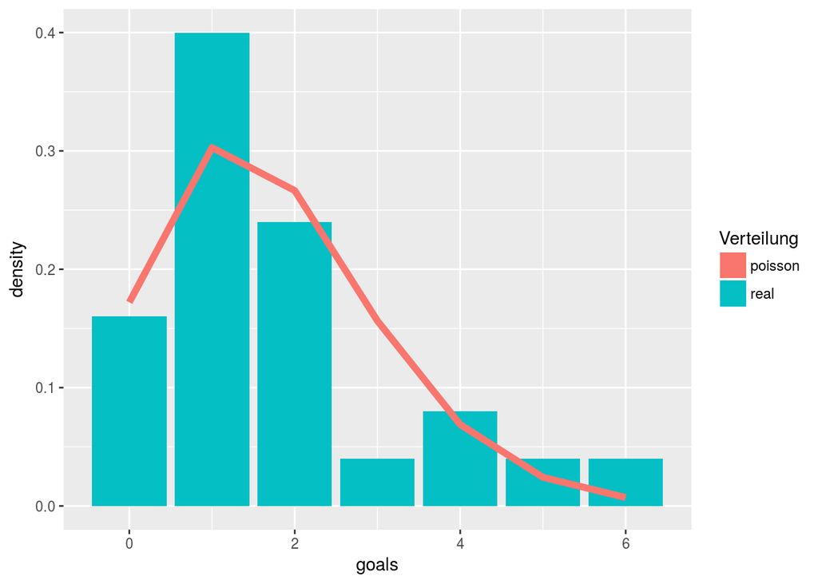

```r
teams.all <- c("Russia", "Portugal", "France", "Argentina", "Saudi Arabia", "Spain", "Australia", "Iceland", "Egypt", "Morocco", "Peru", "Croatia", "Uruguay", "Iran", "Denmark", "Nigeria", "Brazil", "Germany", "Belgium", "Poland", "Switzerland", "Sweden", "Panama", "Senegal", "Costa Rica", "Mexico", "Tunisia", "Colombia", "Serbia", "Korea Republic", "England", "Japan")

some.team <- matches %>%
  dplyr::filter(Home.Team.Name=="Argentina")

# histogram of goals scored
some.home.hist <- some.team %>%
  group_by(Home.Team.Goals) %>%
  summarize(density=n()/nrow(.)) %>%
  mutate(goals = Home.Team.Goals)

#calculate theoretical distribution
some.home.hist$pois <- dpois(some.home.hist$goals, mean(some.team$Home.Team.Goals))

ggplot(some.home.hist)  +
  geom_col(aes(x=goals,y=density, fill=as.factor("real"))) +
  geom_line(aes(x=goals,y=pois, fill=as.factor("poisson")), color="#f8766d", size=2) +
  scale_fill_manual(values=c("#f8766d","#04bfc4"), name="Verteilung")
```

We make the same for the received goals.

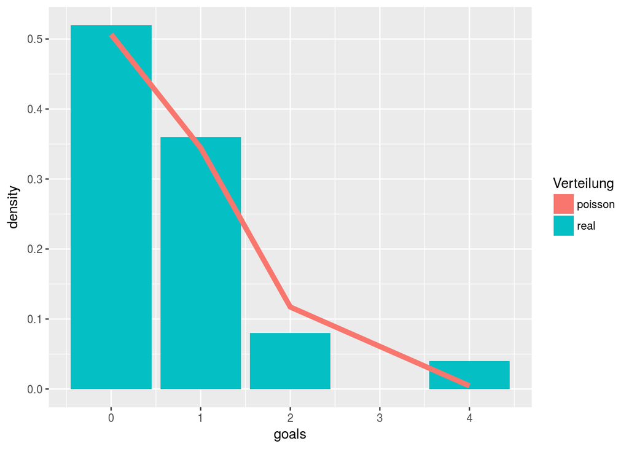

```r
some.away.hist <- some.team %>%
  group_by(Away.Team.Goals) %>%
  summarize(density=n()/nrow(.)) %>%
  mutate(goals = Away.Team.Goals)

some.away.hist$pois <- dpois(some.away.hist$goals, mean(some.team$Away.Team.Goals))

ggplot(some.away.hist)  +
  geom_col(aes(x=goals,y=density, fill=as.factor("real"))) +
  geom_line(aes(x=goals,y=pois, fill=as.factor("poisson")), color="#f8766d", size=2) +
  scale_fill_manual(values=c("#f8766d","#04bfc4"), name="Verteilung")
```

- **Task 18** You do not have to use a statistical model, but if you do, you have to train it. This would require a trainings dataset. This training set would need include at least
- the result of the game
- general information about the game
- information about the home team
- information about the away team

###### Training the Model

Our basic Poisson model uses only minimal information:

- Name of the home-team
- Name of the opponent
- goals scored by the home team

the goals scored becomes our prediction variable.

Additionally we had to include `Panama`, `Peru` and `Iceland` in the training set. Since they have not played in the WoldCup since at least 1990, we assumed they scored 0 goals.

```r
#training the model

matches.a <- matches %>%
  transmute(
    team = Home.Team.Name,
    opponent = Away.Team.Name,
    goals = Home.Team.Goals,
  )
matches.b <- matches %>%
  transmute(
    team = Away.Team.Name,
    opponent = Home.Team.Name,
    goals = Away.Team.Goals,
  )

# include this coutries
rest <- expand.grid(team = c("Panama", "Peru", "Iceland"),
                    opponent = c("Panama", "Peru", "Iceland"),
                    goals = 0
)

model.poisson <- rbind(matches.a, matches.b, rest) %>%
  glm(data=., goals ~ team + opponent, family="poisson")

#head(summary(model.poisson), n = 20)
#print("...")
#tail(summary(model.poisson), n = 20)
```

We use the model the predict the goals scored by the home team. Then we use the same model to predict the goals received with the team and opponent flipped.

```r
predict.wm <- function(home.team, away.team, model) {
  #model=model.poisson
  #home.team="Russia"
  #away.team="Italy"
    input <- data.frame(team=c(home.team, away.team),opponent=c(away.team, home.team))
    input$prediction <- predict(model, newdata=input, type="response")

    # calculate probability matrix
    m <- dpois(0:10, input[1,]$prediction) %o%  dpois(0:10, input[2,]$prediction)

    r <- c(
      'W' = sum(m[lower.tri(m)]),
      'D' = sum(diag(m)),
      'L' = sum(m[upper.tri(m)])
    )
    names(which.max(r))
}
```

```r
prediction <- predict.matrix(teams.all, predict.wm, model.poisson)
peek(prediction, 5)
```

```
##              Russia Portugal France Argentina Saudi Arabia
## Russia       NA     "L"      "L"    "L"       "W"
## Portugal     "W"    NA       "L"    "L"       "W"
## France       "W"    "W"      NA     "D"       "W"
## Argentina    "W"    "W"      "D"    NA        "W"
## Saudi Arabia "L"    "L"      "L"    "L"       NA
```

```r
evaluate.wm(prediction, fifa.results)
```

```
## [1] 0.4285714
```

As a second experiment we trained a new model with information about the team ranks.

- team_rank: the last FIFA rank of the home team
- opponent_rank: the last FIFA rank of the away team

```r
ranks <- med_rank_by_country$last_rank
names(ranks) <- med_rank_by_country$country_full

matches.a.r <- matches.a %>%
  mutate(
    opponent_rank = ranks[opponent],
    team_rank = ranks[team]
  )

matches.b.r <- matches.b %>%
  mutate(
    opponent_rank = ranks[opponent],
    team_rank = ranks[team]
  )

rest.r <- rest %>%
  mutate(
    opponent_rank = 1000,
    team_rank = 1000
  )



model.poisson.rank <- rbind(matches.a.r, matches.b.r, rest.r) %>%
  glm(data=., goals ~ team + opponent + team_rank + opponent_rank, family="poisson")
```

[output not shown]

[output not shown]

#### Alternative Model

As an alternative approach we train or model to predict the goals scored.

```r
set.seed(2)
Result_Home_Team = ifelse(WorldCupMatch[,7] > WorldCupMatch[,8], "W", ifelse(WorldCupMatch[,7] == WorldCupMatch[,8], "D", "L"))



#Get column with Results for the home team into the big Matrix - History of World Cups

Hist_Data = cbind(WorldCupMatch, Result_Home_Team)

colnames(Hist_Data)[21]="Result for Home Team"

HistWDL = Hist_Data %>%
  select(`Year`, `Home.Team.Name`, `Home.Team.Goals`, `Away.Team.Name`, `Away.Team.Goals`) %>%
  group_by(`Home.Team.Name`)

TrainingssetHist = HistWDL[sample(nrow(HistWDL), 4200), ]
TestsetHist = HistWDL[sample(nrow(HistWDL), 100), ]

TestsetHist = na.omit(TestsetHist)
TrainingssetHist = na.omit(TrainingssetHist)

Hist_Model = glm(`Home.Team.Goals` ~ `Home.Team.Name` + `Away.Team.Name` + `Away.Team.Goals`, data = TrainingssetHist)

head(summary(Hist_Model))
```

```
## $call
## glm(formula = Home.Team.Goals ~ Home.Team.Name + Away.Team.Name +
##     Away.Team.Goals, data = TrainingssetHist)
##
## $terms
## Home.Team.Goals ~ Home.Team.Name + Away.Team.Name + Away.Team.Goals
## attr(,"variables")
## list(Home.Team.Goals, Home.Team.Name, Away.Team.Name, Away.Team.Goals)
## attr(,"factors")
##                 Home.Team.Name Away.Team.Name Away.Team.Goals
## Home.Team.Goals              0              0               0
## Home.Team.Name               1              0               0
## Away.Team.Name               0              1               0
## Away.Team.Goals              0              0               1
## attr(,"term.labels")
## [1] "Home.Team.Name"  "Away.Team.Name"  "Away.Team.Goals"
## attr(,"order")
## [1] 1 1 1
## attr(,"intercept")
## [1] 1
## attr(,"response")
## [1] 1
## attr(,".Environment")
## <environment: R_GlobalEnv>
## attr(,"predvars")
## list(Home.Team.Goals, Home.Team.Name, Away.Team.Name, Away.Team.Goals)
## attr(,"dataClasses")
## Home.Team.Goals  Home.Team.Name  Away.Team.Name Away.Team.Goals
##       "numeric"        "factor"        "factor"       "numeric"
##
## $family
##
## Family: gaussian
## Link function: identity
##
##
## $deviance
## [1] 1327.336
##
## $aic
## [1] 2964.414
##
## $contrasts
## $contrasts$Home.Team.Name
## [1] "contr.treatment"
##
## $contrasts$Away.Team.Name
## [1] "contr.treatment"
```

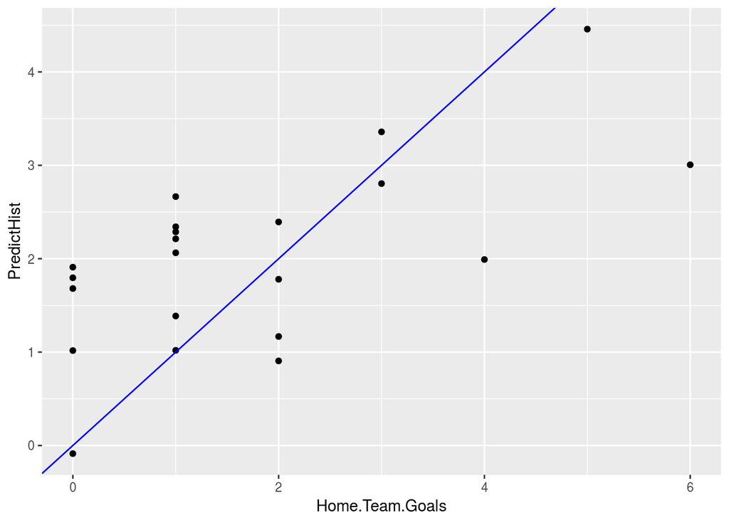

```r
TestsetHist$PredictHist = predict(Hist_Model, newdata = TestsetHist, droplevels = TRUE)


## Visualization of Model
ggplot(data = TestsetHist, aes(x = `Home.Team.Goals`, y = PredictHist))+
  geom_point()+
  geom_abline(color = "blue")
```

```r
fitModel = lm(TestsetHist$`Home.Team.Goals` ~ TestsetHist$PredictHist)

summary(fitModel)
```

```
##
## Call:
## lm(formula = TestsetHist$Home.Team.Goals ~ TestsetHist$PredictHist)
##
## Residuals:
##     Min      1Q  Median      3Q     Max
## -1.6069 -1.0211 -0.1376  0.5808  3.1915
##
## Coefficients:
##                         Estimate Std. Error t value Pr(>|t|)
## (Intercept)              -0.4858     0.6726  -0.722  0.47893
## TestsetHist$PredictHist   1.0960     0.3026   3.622  0.00181 **
## ---
## Signif. codes:  0 '***' 0.001 '**' 0.01 '*' 0.05 '.' 0.1 ' ' 1
##
## Residual standard error: 1.324 on 19 degrees of freedom
## Multiple R-squared:  0.4085, Adjusted R-squared:  0.3773
## F-statistic: 13.12 on 1 and 19 DF,  p-value: 0.001814
```

- **Task 19** (voluntary) Create a list of pariticipating nations for every world cup and scrape their information from the follwing links:

https://www.transfermarkt.de/weltmeisterschaft-2014/teilnehmer/pokalwettbewerb/WM14/saison_id/2013

https://www.transfermarkt.de/weltmeisterschaft-2010/teilnehmer/pokalwettbewerb/WM10/saison_id/2009

https://www.transfermarkt.de/weltmeisterschaft-2006/teilnehmer/pokalwettbewerb/WM06/saison_id/2005

https://www.transfermarkt.de/weltmeisterschaft-2002/teilnehmer/pokalwettbewerb/WM02/saison_id/2001

### Sources

https://en.wikipedia.org/wiki/Statistical_association_football_predictions